# Lecture 6-2

# Introducing data visualization in Python: Matplotlib

## Week 6 Wednesday

## Miles Chen, PhD

### Adapted from *Python for Data Science* by Jake VanderPlas

### References:

https://matplotlib.org/stable/api/pyplot_summary.html

https://matplotlib.org/stable/api/_as_gen/matplotlib.pyplot.html#module-matplotlib.pyplot

### Always: `import matplotlib.pyplot as plt`

```python
import matplotlib.pyplot as plt
import numpy as np
import pandas as pd
```

## Creating a simple plot.

First, we create arrays of the values to plot.

```python
x = np.linspace(0, np.pi * 2, 500)
```

We then calculate the y values we wish to plot. In this case, we'll keep it simple and calculate sin of x (in radians).

```python
y = np.sin(x)
```

# Line Plot

To create a plot, you can call `plt.plot(x, y)`. To have it appear, you call `plt.show()`. `plt.show()` is much like calling `print()`. In Jupyter, if you do not call `plt.show()`, the plot will still often appear, but it is generally considered good practice to call `plt.show()`.

Prior to calling `plt.show()`, you can call optionally other functions which will modify the plot, such as adding a title or changing the axis limits.

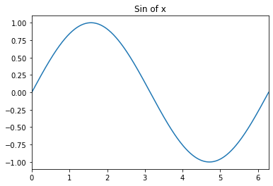

```python
plt.plot(x, y)
plt.title("Sin of x") # optional
plt.xlim(0,2 * np.pi) # optional
plt.show()
```

The default behavior of `plt.plot()` is to plot the points and connect them with lines.

```
[0 1 2 3 4]
[3 2 2 7 0]
```

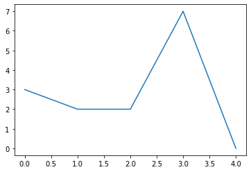

```python
x = np.arange(0, 5, 1)
print(x)
y = np.random.randint(0, 10, 5)
print(y)
plt.plot(x, y)
plt.show()
```

# Scatterplot

If you do not want the points to be connected with a line, you can ask for a scatterplot.

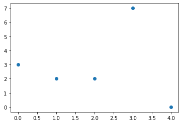

```python
plt.scatter(x,y)
plt.show()
```

# Multiple functions or sequences on the same graph

Repeated calls to `plt.plot()` will add lines to the same plot.

```python
x = np.linspace(0, np.pi * 2, 500)
y = np.sin(x)
z = np.tan(x)
w = np.cos(x)
```

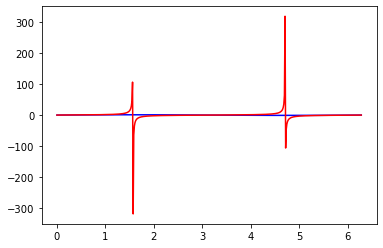

```python
plt.plot(x, y, 'blue')
plt.plot(x, z, 'red')
plt.show() # the scale of the two functions make this graph undesirable
```

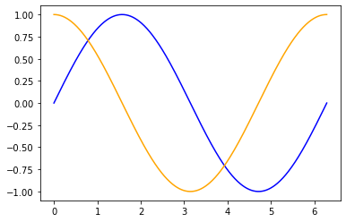

```python
plt.plot(x, y, 'blue')
plt.plot(x, w, 'orange')
plt.show()
```

# changing labels and axis limits

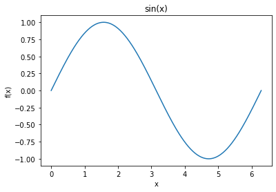

```python
plt.plot(x, y)
plt.title('sin(x)')
plt.xlabel('x')
plt.ylabel('f(x)')
plt.show()
```

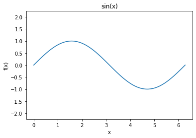

```python
plt.plot(x, y)
plt.title('sin(x)')
plt.xlabel('x')
plt.ylabel('f(x)')
plt.xlim(0, 2 * np.pi)
plt.axis('equal')  # aspect ratio # investigate later
plt.show()
```

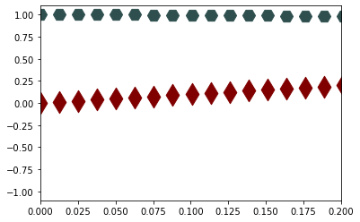

```python
plt.scatter(x, y, s = 300, marker = 'd', color = 'maroon')
plt.scatter(x, w, s = 200, marker = 'H', color = 'darkslategrey')
plt.xlim([0, .2])
plt.show()
```

# Plot options: colors

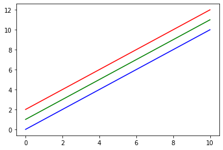

```python
# colors
x = np.linspace(0, 10, 1000)
plt.plot(x, x, color = 'b')
plt.plot(x, x+1, color = 'g')
plt.plot(x, x+2, color = 'r')
plt.show()
```

### List of colors and single character shortcuts

| character | color |
| --- | --- |
| 'b' | blue |
| 'g' | green |
| 'r' | red |
| 'c' | cyan |
| 'm' | magenta |
| 'y' | yellow |
| 'k' | black |
| 'w' | white |

List of Named Colors: https://matplotlib.org/stable/gallery/color/named_colors.html

# Plot options: line type

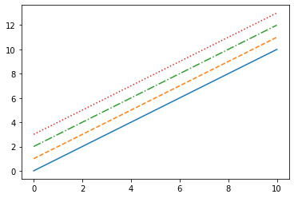

```python
# line style
x = np.linspace(0, 10, 1000)
plt.plot(x,  x , linestyle = '-')  # solid
plt.plot(x, x+1, linestyle = '--') # dashed
plt.plot(x, x+2, linestyle = '-.') # dash dot
plt.plot(x, x+3, linestyle = ':')  # dotted
plt.show()

# default behavior uses different colors for multiple lines
```

https://matplotlib.org/stable/gallery/lines_bars_and_markers/linestyles.html

# Plot options: figure size, axis, title

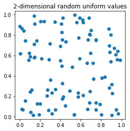

```python
np.random.seed(1)
x = np.random.random(100)
y = np.random.random(100)
plt.figure(figsize = (4,4))  # define the properties of the figure first
plt.scatter(x,y)             # then add content
plt.axis('equal')            # alter properties
plt.title('2-dimensional random uniform values')
plt.show()
```

documentation for figure() https://matplotlib.org/stable/api/_as_gen/matplotlib.pyplot.figure.html

### adding point size and color options to a scatter plot

```python
z = 100 * np.random.randint(1,11,100)  # use for size
w = np.random.randint(0,5,100) # use for color
print(z)
print(w)
```

```
[1000  600  500 1000  600  300  600  700  700  900  800  800  800  300
  700  100  600  300  200  900  600 1000  500 1000  200  300  100  500
  800  100  700  300  500  400  700  800  700  400  100  700  500  800
  700  300 1000  600 1000 1000 1000  900  700  500  300 1000  500  100
  100  400  500 1000  400 1000  200  300  600  500  100  900  300  400
 1000 1000  500  500  900  300  200  700  400  900 1000  800  100  600
  300  300  900  600  100  600 1000  900  700  700  100  500  800  400
  100  200]
[2 0 1 4 2 3 4 4 2 1 2 0 3 3 2 0 0 0 0 2 4 0 4 1 2 1 2 4 1 3 1 1 2 4 1 0 2
 1 2 0 0 3 4 1 0 4 0 3 2 4 3 2 4 2 4 0 0 4 2 2 4 2 3 0 0 4 3 4 3 3 4 0 3 1
 4 4 3 2 2 2 2 2 0 2 1 2 3 0 0 1 1 3 3 3 1 3 3 3 1 3]
```

```python
colors = np.array(['r','b','g','m','y'])
c = colors[w]
print(c)
```

```
['g' 'r' 'b' 'y' 'g' 'm' 'y' 'y' 'g' 'b' 'g' 'r' 'm' 'm' 'g' 'r' 'r' 'r'
 'r' 'g' 'y' 'r' 'y' 'b' 'g' 'b' 'g' 'y' 'b' 'm' 'b' 'b' 'g' 'y' 'b' 'r'
 'g' 'b' 'g' 'r' 'r' 'm' 'y' 'b' 'r' 'y' 'r' 'm' 'g' 'y' 'm' 'g' 'y' 'g'
 'y' 'r' 'r' 'y' 'g' 'g' 'y' 'g' 'm' 'r' 'r' 'y' 'm' 'y' 'm' 'm' 'y' 'r'
 'm' 'b' 'y' 'y' 'm' 'g' 'g' 'g' 'g' 'g' 'r' 'g' 'b' 'g' 'm' 'r' 'r' 'b'
 'b' 'm' 'm' 'm' 'b' 'm' 'm' 'm' 'b' 'm']
```

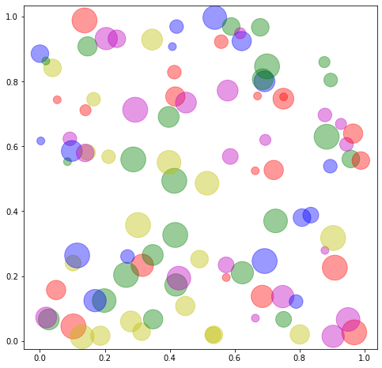

```python
# we can map the property size (s) to a variable z
# we can map the color (c) to a variable c
plt.figure(figsize = (8,8))
plt.scatter(x, y, s = z, c = c, alpha = 0.4 )  # alpha modifies transparency
plt.axis('equal')
plt.show()
```

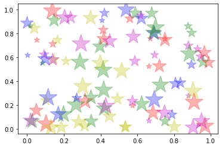

```python
# you can change the point markers
plt.scatter(x, y, s = z, c = c, marker = "*", alpha = 0.3)
# But you can't map the markers to a variable
plt.show()
```

| character | description |
| --- | --- |
| '.' | point marker |
| ',' | pixel marker |
| 'o' | circle marker |
| 'v' | triangle_down marker |
| '^' | triangle_up marker |
| '<' | triangle_left marker |
| '>' | triangle_right marker |
| '1' | tri_down marker |
| '2' | tri_up marker |
| '3' | tri_left marker |
| '4' | tri_right marker |
| 's' | square marker |
| 'p' | pentagon marker |
| '*' | star marker |
| 'h' | hexagon1 marker |
| 'H' | hexagon2 marker |
| '+' | plus marker |
| 'x' | x marker |
| 'D' | diamond marker |
| 'd' | thin_diamond marker |

https://matplotlib.org/stable/gallery/lines_bars_and_markers/marker_reference.html

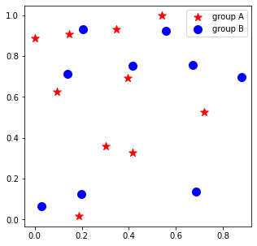

```python
# You can call 'scatter' multiple times to plot different groups, each with its own label
# then call plt.legend() to add a legend with the appropriate labels
plt.figure(figsize = (5,5))
plt.scatter(x[0:10] , y[0:10] , s = 100, c = 'red' , marker = "*", label = 'group A')
plt.scatter(x[11:20], y[11:20], s = 100, c = 'blue', marker = "o", label = 'group B')
plt.legend()
plt.show()
```

# Complex layouts with subplots

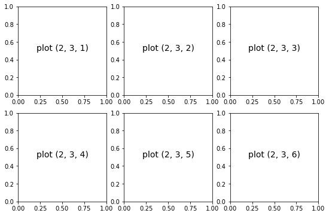

```python
# Subplots
plt.figure(figsize = (9,6))
for i in range(1, 7):
    plt.subplot(2, 3, i)   # two rows of subplots, three columns of plots, work in plot i
    plt.text(0.5, 0.5, 'plot ' + str((2, 3, i)), fontsize = 14, ha='center')
    # plt.text adds text, first two will be the xy position, the character string
```